# Part iiC: Regression model predictions

INFSCI 2595 Final

Ben Stein

4/27/2022

# About this document

In this document, I make predictions with two of my top-performing regression models in order to understand trends between the predicted log-response and the observed log-response across variables of interest.

# Setup

## Libraries and tools

```r
library(tidyverse)
source("./tools.R")
```

## Data

```r
df <- load_project_data(center_and_scale = TRUE) %>%
  select(-outcome_numeric)

df %>% glimpse()
```

```
## Rows: 677
## Columns: 36
## $ region       <fct> XX, XX, XX, XX, XX, XX, XX, XX, XX, XX, XX, XX, XX, XX, X~
## $ customer     <fct> B, B, B, B, B, B, B, B, B, B, B, B, B, B, B, B, B, B, B, ~
## $ xb_01        <dbl> 0.30863578, -1.17801052, -0.68246175, -0.42477639, -0.410~
## $ xb_02        <dbl> -0.52769021, -1.43287502, -1.13114675, 1.58440769, 0.0757~
## $ xb_03        <dbl> 0.92465680, -0.07214679, 0.26012107, -2.39802182, -0.7366~
## $ xn_01        <dbl> 0.82042446, 0.25145112, 0.25145112, -0.01406977, -0.40929~
## $ xn_02        <dbl> -0.2245211, -0.5623007, 0.1132584, 1.8021561, -0.2245211,~
## $ xn_03        <dbl> 1.2762480, 0.9010765, 0.1507336, -0.9747808, -1.3499523, ~
## $ xa_01        <dbl> 1.00106429, -1.29333076, 0.23626594, -0.25320501, -0.4134~
## $ xa_02        <dbl> -0.1773302, -1.4605523, -0.6050709, 2.2465338, 0.5355710,~
## $ xa_03        <dbl> 1.4593153, -0.1494432, 0.9230625, -1.9369527, -1.0431979,~
## $ xb_04        <dbl> 0.26039081, -0.22110912, -0.22110912, -0.37271282, 0.1035~
## $ xb_05        <dbl> 0.86178234, 0.55137413, 0.55137413, -2.24229976, -0.84546~
```

[output cut: 23 more lines]

## Models to evaluate

I chose model 5 as the best-performing model from iiA and model 6 because while it seems like it may be overfit, I’m curious about how its prediction and confidence trends relate to model 6.

```r
lm_model5 <- readr::read_rds("./models/lm_rank1_model5.rds")
lm_model6 <- readr::read_rds("./models/lm_rank3_model6.rds")
```

## Variables of interest

Based on performance in iiA, variables of interest are `region`, `customer`, and two top-performing sentiment variables (`xb_07` and `xn_08`).

# Analysis

Let’s apply what we know about important variables to these models. Spoiler alert: we need a function that generates confidence and prediction intervals for a given model and visualization grid.

```r
generate_preds <- function(model, viz_grid) {
  preds <- predict(model, viz_grid, interval = "confidence") %>%
    as.data.frame %>%
    as_tibble %>%
    rename(
      pred = fit,
      ci_lwr = lwr,
      ci_upr = upr
    ) %>%
    bind_cols(
      predict(
        model,
        viz_grid,
        interval = "prediction"
      ) %>%
        as.data.frame %>%
        as_tibble %>%
        select(
          pred_lwr = lwr,
          pred_upr = upr
        )
    )

  viz_grid %>% bind_cols(preds)
}
```

## Model 5

Model 5 includes `customer` and both of the sentiment predictors. Let’s explore combinations of these three.

### `customer` and `xb_07`

We need a tibble that varies the two variables we want to examine and holds the other variables constant. Let’s make it.

```r
lm_model5_xb_07_vizgrid <- append(
  expand.grid(
    customer = df$customer %>% unique(),
    xb_07 = seq(
      min(df$xb_07),
      max(df$xb_07),
      length.out = 101
    )
  ),
  df %>%
    select(
      -customer,
      -region,
      -response_log,
      -xb_07
    ) %>%
    colMeans
) %>% as_tibble

lm_model5_xb_07_vizgrid
```

```
## # A tibble: 909 x 34
##    customer xb_07    xb_01    xb_02    xb_03    xn_01    xn_02    xn_03    xa_01
##    <fct>    <dbl>    <dbl>    <dbl>    <dbl>    <dbl>    <dbl>    <dbl>    <dbl>
##  1 B        -3.59 3.35e-17 7.56e-17 9.47e-18 6.25e-18 3.31e-17 2.16e-17 1.45e-16
##  2 Other    -3.59 3.35e-17 7.56e-17 9.47e-18 6.25e-18 3.31e-17 2.16e-17 1.45e-16
##  3 D        -3.59 3.35e-17 7.56e-17 9.47e-18 6.25e-18 3.31e-17 2.16e-17 1.45e-16
##  4 E        -3.59 3.35e-17 7.56e-17 9.47e-18 6.25e-18 3.31e-17 2.16e-17 1.45e-16
##  5 G        -3.59 3.35e-17 7.56e-17 9.47e-18 6.25e-18 3.31e-17 2.16e-17 1.45e-16
##  6 Q        -3.59 3.35e-17 7.56e-17 9.47e-18 6.25e-18 3.31e-17 2.16e-17 1.45e-16
##  7 A        -3.59 3.35e-17 7.56e-17 9.47e-18 6.25e-18 3.31e-17 2.16e-17 1.45e-16
##  8 K        -3.59 3.35e-17 7.56e-17 9.47e-18 6.25e-18 3.31e-17 2.16e-17 1.45e-16
##  9 M        -3.59 3.35e-17 7.56e-17 9.47e-18 6.25e-18 3.31e-17 2.16e-17 1.45e-16
## 10 B        -3.49 3.35e-17 7.56e-17 9.47e-18 6.25e-18 3.31e-17 2.16e-17 1.45e-16
## # ... with 899 more rows, and 25 more variables: xa_02 <dbl>, xa_03 <dbl>,
## #   xb_04 <dbl>, xb_05 <dbl>, xb_06 <dbl>, xb_08 <dbl>, xn_04 <dbl>,
## #   xn_05 <dbl>, xn_06 <dbl>, xn_07 <dbl>, xn_08 <dbl>, xa_04 <dbl>,
## #   xa_05 <dbl>, xa_06 <dbl>, xa_07 <dbl>, xa_08 <dbl>, xw_01 <dbl>,
## #   xw_02 <dbl>, xw_03 <dbl>, xs_01 <dbl>, xs_02 <dbl>, xs_03 <dbl>,
## #   xs_04 <dbl>, xs_05 <dbl>, xs_06 <dbl>
```

We also need predictions for our visualization grid:

```r
df_lm_model5_xb_07 <- generate_preds(lm_model5, lm_model5_xb_07_vizgrid)
```

We can finally visualize trends!

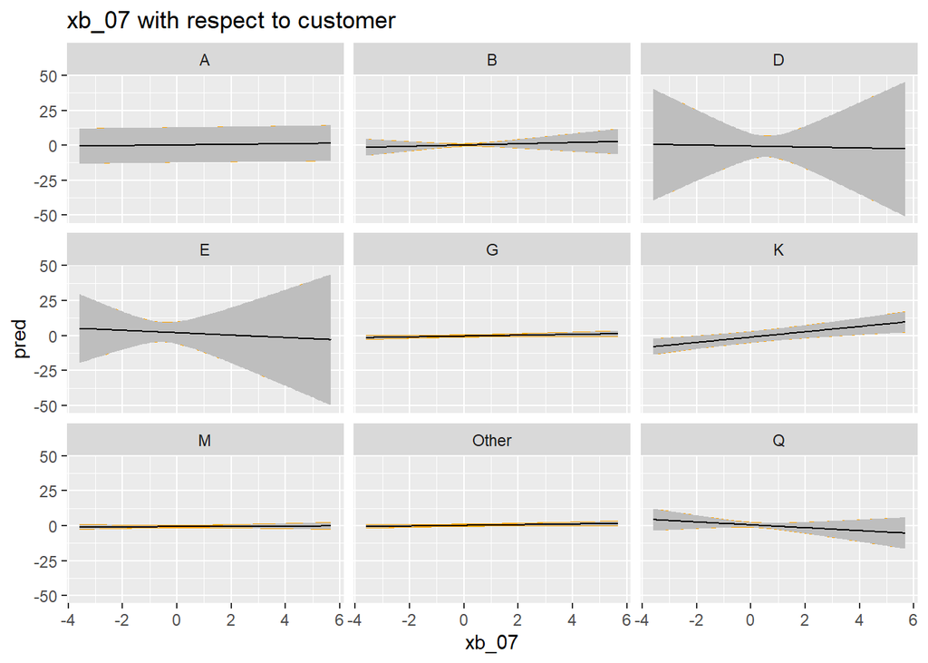

```r
df_lm_model5_xb_07 %>%
    ggplot(mapping = aes(x = xb_07)) +
    ggtitle("xb_07 with respect to customer") +
    geom_ribbon(mapping = aes(ymin = pred_lwr, ymax = pred_upr), fill = "orange") +
    geom_ribbon(mapping = aes(ymin = ci_lwr, ymax = ci_upr), fill = "gray") +
    geom_line(mapping = aes(y = pred)) +
    facet_wrap(~ customer)
```

## Model 6

This model doesn’t have an important categorical to examine, so let’s look at just the sentiment predictors. We already took a close look at `xb_07`, so let’s facet `xn_08` by `xb_07`.

### `xn_08` faceted by `xb_07`

```r
lm_model6_xb_07_xn_08_vizgrid <- append(
  expand.grid(
    xn_08 = seq(
      min(df$xn_08),
      max(df$xn_08),
      length.out = 101
    ),
    xb_07 = seq(
      min(df$xb_07),
      max(df$xb_07),
      length.out = 9
    ),
    # the most common level of these factors
    # borrowed from https://stackoverflow.com/questions/18433647/how-to-get-the-most-frequent-level-of-a-categorical-variable-in-r
    customer = which.max(table(df$customer)),
    region = which.max(table(df$region))
  ),
  df %>%
    select(
      -customer,
      -region,
      -response_log,
      -xb_07,
      -xn_08
    ) %>%
    colMeans
) %>% as_tibble

lm_model6_xb_07_xn_08_vizgrid
```

```
## # A tibble: 909 x 35
##    xn_08 xb_07 customer region    xb_01    xb_02    xb_03    xn_01    xn_02
##    <dbl> <dbl>    <int>  <int>    <dbl>    <dbl>    <dbl>    <dbl>    <dbl>
##  1 -3.69 -3.59        8      3 3.35e-17 7.56e-17 9.47e-18 6.25e-18 3.31e-17
##  2 -3.60 -3.59        8      3 3.35e-17 7.56e-17 9.47e-18 6.25e-18 3.31e-17
##  3 -3.51 -3.59        8      3 3.35e-17 7.56e-17 9.47e-18 6.25e-18 3.31e-17
##  4 -3.43 -3.59        8      3 3.35e-17 7.56e-17 9.47e-18 6.25e-18 3.31e-17
##  5 -3.34 -3.59        8      3 3.35e-17 7.56e-17 9.47e-18 6.25e-18 3.31e-17
##  6 -3.25 -3.59        8      3 3.35e-17 7.56e-17 9.47e-18 6.25e-18 3.31e-17
##  7 -3.16 -3.59        8      3 3.35e-17 7.56e-17 9.47e-18 6.25e-18 3.31e-17
##  8 -3.07 -3.59        8      3 3.35e-17 7.56e-17 9.47e-18 6.25e-18 3.31e-17
##  9 -2.98 -3.59        8      3 3.35e-17 7.56e-17 9.47e-18 6.25e-18 3.31e-17
## 10 -2.89 -3.59        8      3 3.35e-17 7.56e-17 9.47e-18 6.25e-18 3.31e-17
## # ... with 899 more rows, and 26 more variables: xn_03 <dbl>, xa_01 <dbl>,
## #   xa_02 <dbl>, xa_03 <dbl>, xb_04 <dbl>, xb_05 <dbl>, xb_06 <dbl>,
## #   xb_08 <dbl>, xn_04 <dbl>, xn_05 <dbl>, xn_06 <dbl>, xn_07 <dbl>,
## #   xa_04 <dbl>, xa_05 <dbl>, xa_06 <dbl>, xa_07 <dbl>, xa_08 <dbl>,
## #   xw_01 <dbl>, xw_02 <dbl>, xw_03 <dbl>, xs_01 <dbl>, xs_02 <dbl>,
## #   xs_03 <dbl>, xs_04 <dbl>, xs_05 <dbl>, xs_06 <dbl>
```

Make predictions and visualize trends:

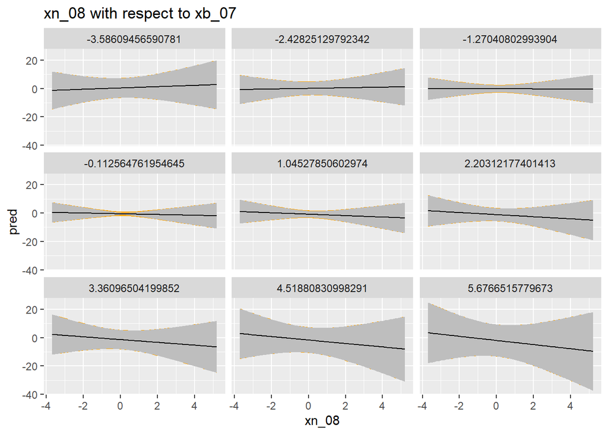

```r
generate_preds(lm_model6, lm_model6_xb_07_xn_08_vizgrid) %>%
    ggplot(mapping = aes(x = xn_08)) +
    ggtitle("xn_08 with respect to xb_07") +
    geom_ribbon(mapping = aes(ymin = pred_lwr, ymax = pred_upr), fill = "orange") +
    geom_ribbon(mapping = aes(ymin = ci_lwr, ymax = ci_upr), fill = "gray") +
    geom_line(mapping = aes(y = pred)) +
    facet_wrap(~ xb_07)
```

This is harder to interpret, but my read here is that at very high levels of `xb_07`, `xn_08` predicts with greater uncertainty. The bow-tie shape of all facets seems to suggest that extreme values of sentiment result in greater uncertainty. We can also see that uncertainty increases at the lower and higher cut points of `xb_07` (i.e. facets in the top and bottom rows have more uncertainty). So the moral of the story is… keep your customer relationships on a relatively even keel?

FYI: this is my favorite skill I’ve learned in this class. Holding other variables constant in order to determine how one variable influences uncertainty is super cool. I’m confident that my interpretation is various shades of rudimentary and incorrect, but I still think this is a really interesting technique.